# Random Forest - Case

## Problem

Many of LionBase's client inquiries come from early-stage startups. For early-stage startups, one of the most crucial steps that must be taken is to raise money. Kickstarter is a very popular crowdraising platform, and all money received through it does not come at the expense of equity. We decided to see if we could build a model to help startups interested in fundraising through Kickstarter predict the success of their campaign.

In this case, you will learn how to develop and iterate on a random forest model.

## Step 1: Import Modules

```python
import numpy as np
import pandas as pd
import matplotlib.pyplot as plt
from sklearn.model_selection import train_test_split
from sklearn.ensemble import RandomForestClassifier
from sklearn.metrics import accuracy_score
import time
from sklearn.metrics import confusion_matrix
% matplotlib inline
```

## Step 2: Read Data

```python
df = pd.read_csv('data/kickstarter.csv')
```

```python
df.shape
```

```
(192548, 20)
```

```python
df.columns
```

```
Index(['id', 'name', 'currency', 'main_category', 'sub_category',
       'launched_at', 'deadline', 'duration', 'goal_usd', 'city', 'state',
       'country', 'blurb_length', 'name_length', 'status', 'start_month',
       'end_month', 'start_Q', 'end_Q', 'usd_pledged'],
      dtype='object')
```

```python
df.head()
```

|  | id | name | currency | main_category | sub_category | launched_at | deadline | duration | goal_usd | city | state | country | blurb_length | name_length | status | start_month | end_month | start_Q | end_Q | usd_pledged |
| --- | --- | --- | --- | --- | --- | --- | --- | --- | --- | --- | --- | --- | --- | --- | --- | --- | --- | --- | --- | --- |
| 0 | 1687733153 | Socks of Speed and Socks of Elvenkind | USD | games | Tabletop Games | 2018-10-30 20:00:02 | 2018-11-15 17:59:00 | 16.0 | 2000.00000 | Menasha | WI | US | 14 | 7 | successful | 10 | 11 | Q4 | Q4 | 6061.00000 |
| 1 | 227936657 | Power Punch Boot Camp: An All-Ages Graphic Novel | GBP | comics | Comic Books | 2018-08-06 10:00:43 | 2018-09-05 10:00:43 | 30.0 | 3870.99771 | Shepperton | England | GB | 24 | 8 | successful | 8 | 9 | Q3 | Q3 | 3914.50512 |
| 2 | 454186436 | Live Printing with SX8: "Squeegee Pulp Up" | USD | fashion | Apparel | 2017-06-09 15:41:03 | 2017-07-09 15:41:03 | 30.0 | 1100.00000 | Manhattan | NY | US | 21 | 7 | successful | 6 | 7 | Q2 | Q3 | 1110.00000 |
| 3 | 629469071 | Lost Dog Street Band's Next Album | USD | music | Country & Folk | 2014-09-25 18:46:01 | 2014-11-10 06:00:00 | 45.0 | 3500.00000 | Nashville | TN | US | 15 | 6 | successful | 9 | 11 | Q3 | Q4 | 4807.00000 |
| 4 | 183973060 | Qto-X, a Tiny Lantern | USD | technology | Gadgets | 2016-11-28 16:35:11 | 2017-01-27 16:35:11 | 60.0 | 30000.00000 | Troy | MI | US | 15 | 4 | successful | 11 | 1 | Q4 | Q1 | 40368.00000 |

## Step 3: Get Subset of Columns

```python
selected_columns = ['currency', 'main_category', 'sub_category',
       'duration', 'goal_usd',
       'country', 'blurb_length', 'name_length', 'status', 'start_month',
       'end_month', 'start_Q', 'end_Q', 'usd_pledged'] # subset columns
df = df[selected_columns] # subset dataframe
```

I have selected columns which are not unique variables (e.x. the ID column). I have also removed city and state since they likely have high correlation with country.

```python
df.head()
```

|  | currency | main_category | sub_category | duration | goal_usd | country | blurb_length | name_length | status | start_month | end_month | start_Q | end_Q | usd_pledged |
| --- | --- | --- | --- | --- | --- | --- | --- | --- | --- | --- | --- | --- | --- | --- |
| 0 | USD | games | Tabletop Games | 16.0 | 2000.00000 | US | 14 | 7 | successful | 10 | 11 | Q4 | Q4 | 6061.00000 |
| 1 | GBP | comics | Comic Books | 30.0 | 3870.99771 | GB | 24 | 8 | successful | 8 | 9 | Q3 | Q3 | 3914.50512 |
| 2 | USD | fashion | Apparel | 30.0 | 1100.00000 | US | 21 | 7 | successful | 6 | 7 | Q2 | Q3 | 1110.00000 |
| 3 | USD | music | Country & Folk | 45.0 | 3500.00000 | US | 15 | 6 | successful | 9 | 11 | Q3 | Q4 | 4807.00000 |
| 4 | USD | technology | Gadgets | 60.0 | 30000.00000 | US | 15 | 4 | successful | 11 | 1 | Q4 | Q1 | 40368.00000 |

```python
df.shape
```

```
(192548, 14)
```

## Step 4: Split Features and Dependent Variable

```python
X = df.loc[:, df.columns != 'status'] # get all columns that are not status for the features
X
```

|  | currency | main_category | sub_category | duration | goal_usd | country | blurb_length | name_length | start_month | end_month | start_Q | end_Q | usd_pledged |
| --- | --- | --- | --- | --- | --- | --- | --- | --- | --- | --- | --- | --- | --- |
| 0 | USD | games | Tabletop Games | 16.0 | 2000.000000 | US | 14 | 7 | 10 | 11 | Q4 | Q4 | 6061.000000 |
| 1 | GBP | comics | Comic Books | 30.0 | 3870.997710 | GB | 24 | 8 | 8 | 9 | Q3 | Q3 | 3914.505120 |
| 2 | USD | fashion | Apparel | 30.0 | 1100.000000 | US | 21 | 7 | 6 | 7 | Q2 | Q3 | 1110.000000 |
| 3 | USD | music | Country & Folk | 45.0 | 3500.000000 | US | 15 | 6 | 9 | 11 | Q3 | Q4 | 4807.000000 |
| 4 | USD | technology | Gadgets | 60.0 | 30000.000000 | US | 15 | 4 | 11 | 1 | Q4 | Q1 | 40368.000000 |
| 5 | USD | music | Country & Folk | 30.0 | 7500.000000 | US | 11 | 4 | 1 | 2 | Q1 | Q1 | 7770.000000 |
| 6 | USD | film & video | Drama | 30.0 | 6000.000000 | US | 3 | 2 | 8 | 9 | Q3 | Q3 | 6500.000000 |
| 7 | EUR | design | Graphic Design | 30.0 | 1133.687880 | DE | 17 | 8 | 7 | 8 | Q3 | Q3 | 1168.384000 |
| 8 | USD | art | Sculpture | 30.0 | 3000.000000 | US | 19 | 3 | 9 | 10 | Q3 | Q4 | 3511.000000 |
| 9 | USD | music | Country & Folk | 60.0 | 1000.000000 | US | 27 | 10 | 3 | 4 | Q1 | Q2 | 1770.850000 |
| 10 | CAD | comics | Comic Books | 30.0 | 1135.634085 | CA | 23 | 6 | 9 | 10 | Q3 | Q4 | 1388.850786 |
| 11 | USD | fashion | Apparel | 20.0 | 9000.000000 | US | 22 | 6 | 4 | 4 | Q2 | Q2 | 10390.000000 |
| 12 | USD | games | Tabletop Games | 31.0 | 17500.000000 | US | 27 | 4 | 7 | 8 | Q3 | Q3 | 45707.000000 |
| 13 | USD | design | Graphic Design | 9.0 | 100.000000 | US | 18 | 6 | 1 | 2 | Q1 | Q1 | 308.000000 |
| 14 | USD | technology | Gadgets | 36.0 | 50000.000000 | US | 21 | 10 | 4 | 6 | Q2 | Q2 | 117240.000000 |
| 15 | USD | comics | Anthologies | 21.0 | 6000.000000 | US | 10 | 5 | 6 | 6 | Q2 | Q2 | 7320.000000 |
| 16 | USD | music | Country & Folk | 30.0 | 5000.000000 | US | 12 | 4 | 12 | 1 | Q4 | Q1 | 5000.000000 |
| 17 | USD | fashion | Apparel | 30.0 | 10000.000000 | US | 19 | 6 | 6 | 7 | Q2 | Q3 | 15533.000000 |
| 18 | USD | music | Country & Folk | 30.0 | 17000.000000 | US | 27 | 7 | 8 | 9 | Q3 | Q3 | 17905.000000 |
| 19 | GBP | games | Tabletop Games | 14.0 | 645.166285 | GB | 23 | 9 | 11 | 11 | Q4 | Q4 | 923.210604 |
| 20 | USD | music | Country & Folk | 30.0 | 4000.000000 | US | 23 | 5 | 7 | 8 | Q3 | Q3 | 4075.550000 |
| 21 | USD | music | Country & Folk | 30.0 | 8000.000000 | US | 24 | 8 | 11 | 12 | Q4 | Q4 | 9260.000000 |
| 22 | USD | comics | Comic Books | 30.0 | 2500.000000 | US | 11 | 5 | 9 | 10 | Q3 | Q4 | 2606.010000 |
| 23 | GBP | games | Tabletop Games | 30.0 | 1290.332570 | GB | 7 | 3 | 12 | 1 | Q4 | Q1 | 2799.330408 |
| 24 | GBP | film & video | Drama | 31.0 | 903.232799 | GB | 26 | 2 | 12 | 1 | Q4 | Q1 | 1867.343224 |
| 25 | USD | technology | DIY Electronics | 33.0 | 2000.000000 | US | 20 | 9 | 6 | 8 | Q2 | Q3 | 5047.000000 |
| 26 | USD | art | Sculpture | 42.0 | 2000.000000 | US | 11 | 4 | 10 | 12 | Q4 | Q4 | 5002.000000 |
| 27 | USD | art | Sculpture | 32.0 | 2400.000000 | US | 15 | 6 | 10 | 11 | Q4 | Q4 | 4798.000000 |
| 28 | USD | technology | Camera Equipment | 31.0 | 20000.000000 | US | 8 | 5 | 11 | 12 | Q4 | Q4 | 21219.000000 |
| 29 | USD | journalism | Journalism | 28.0 | 250.000000 | US | 19 | 4 | 4 | 5 | Q2 | Q2 | 270.000000 |
| ... | ... | ... | ... | ... | ... | ... | ... | ... | ... | ... | ... | ... | ... |
| 192518 | USD | food | Drinks | 30.0 | 30000.000000 | US | 17 | 9 | 12 | 1 | Q4 | Q1 | 1.000000 |
| 192519 | NZD | food | Vegan | 30.0 | 54622.422400 | NZ | 18 | 6 | 6 | 7 | Q2 | Q3 | 299.446451 |
| 192520 | USD | technology | Flight | 30.0 | 10000.000000 | US | 21 | 7 | 6 | 7 | Q2 | Q3 | 21.000000 |
| 192521 | GBP | food | Drinks | 30.0 | 32162.283250 | GB | 15 | 2 | 12 | 1 | Q4 | Q1 | 64.253043 |
| 192522 | USD | food | Drinks | 30.0 | 25000.000000 | US | 25 | 3 | 2 | 3 | Q1 | Q1 | 212.000000 |
| 192523 | AUD | art | Digital Art | 30.0 | 10677.220500 | AU | 14 | 2 | 1 | 2 | Q1 | Q1 | 0.000000 |
| 192524 | GBP | food | Drinks | 53.0 | 32162.283250 | GB | 18 | 2 | 11 | 1 | Q4 | Q1 | 60.309323 |
| 192525 | USD | publishing | Art Books | 41.0 | 50000.000000 | US | 23 | 4 | 11 | 1 | Q4 | Q1 | 500.000000 |
| 192526 | USD | art | Mixed Media | 30.0 | 10000.000000 | US | 19 | 3 | 3 | 4 | Q1 | Q2 | 0.000000 |
| 192527 | USD | technology | Robots | 30.0 | 15000.000000 | US | 4 | 3 | 11 | 12 | Q4 | Q4 | 31.000000 |
| 192528 | USD | publishing | Art Books | 30.0 | 4500.000000 | US | 14 | 1 | 1 | 2 | Q1 | Q1 | 1119.000000 |
| 192529 | USD | art | Performance Art | 60.0 | 4000.000000 | US | 22 | 4 | 2 | 4 | Q1 | Q2 | 25.000000 |
| 192530 | USD | food | Drinks | 60.0 | 100000.000000 | US | 24 | 3 | 8 | 10 | Q3 | Q4 | 0.000000 |
| 192531 | USD | food | Drinks | 30.0 | 10000.000000 | US | 21 | 4 | 2 | 3 | Q1 | Q1 | 0.000000 |
| 192532 | USD | art | Digital Art | 14.0 | 10000.000000 | US | 21 | 5 | 5 | 5 | Q2 | Q2 | 0.000000 |
| 192533 | USD | photography | Fine Art | 10.0 | 400.000000 | US | 23 | 7 | 1 | 1 | Q1 | Q1 | 32.000000 |
| 192534 | USD | publishing | Anthologies | 30.0 | 2000.000000 | US | 21 | 5 | 12 | 1 | Q4 | Q1 | 16.000000 |
| 192535 | USD | food | Drinks | 30.0 | 27000.000000 | US | 12 | 6 | 6 | 7 | Q2 | Q3 | 15621.000000 |
| 192536 | USD | film & video | Animation | 30.0 | 15000.000000 | US | 21 | 8 | 3 | 4 | Q1 | Q2 | 7210.000000 |
| 192537 | GBP | food | Drinks | 30.0 | 128649.133000 | GB | 15 | 3 | 8 | 9 | Q3 | Q3 | 2604.381436 |
| 192538 | USD | film & video | Animation | 30.0 | 60000.000000 | US | 25 | 5 | 11 | 12 | Q4 | Q4 | 1711.000000 |
| 192539 | USD | publishing | Art Books | 30.0 | 9000.000000 | US | 17 | 3 | 11 | 12 | Q4 | Q4 | 0.000000 |
| 192540 | GBP | music | Punk | 60.0 | 1286.491330 | GB | 21 | 2 | 4 | 5 | Q2 | Q2 | 50.214199 |
| 192541 | USD | food | Drinks | 34.0 | 30000.000000 | US | 20 | 3 | 12 | 1 | Q4 | Q1 | 150.000000 |
| 192542 | EUR | food | Drinks | 30.0 | 20304.339480 | DE | 14 | 7 | 3 | 4 | Q1 | Q2 | 270.517856 |
| 192543 | NOK | food | Drinks | 60.0 | 57858.665000 | NO | 21 | 3 | 10 | 12 | Q4 | Q4 | 1.224260 |
| 192544 | NOK | technology | Fabrication Tools | 47.0 | 115717.330000 | NO | 18 | 2 | 11 | 12 | Q4 | Q4 | 157.273939 |
| 192545 | USD | food | Drinks | 30.0 | 30000.000000 | US | 13 | 3 | 2 | 3 | Q1 | Q1 | 0.000000 |
| 192546 | USD | art | Conceptual Art | 60.0 | 1200.000000 | US | 3 | 3 | 8 | 10 | Q3 | Q4 | 143.000000 |
| 192547 | USD | crafts | DIY | 60.0 | 7600.000000 | US | 20 | 3 | 12 | 2 | Q4 | Q1 | 311.000000 |

192548 rows × 13 columns

```python
X.shape
```

```
(192548, 13)
```

```python
y = df['status'] # get the status column as the y feature
y.value_counts() # check class balance
```

```
successful    117307
failed         75241
Name: status, dtype: int64
```

## Step 5: One-Hot-Encode Categorical Variables

This allows us to make all columns numeric so we can run the random forest algorithm!

```python
X = pd.get_dummies(X) # one hot encodes categorical variables
```

```
One hot encoding is a process where a categorical variable is converted into a binary representation

E.x. Suppose we have class 1, 2, and 3 in one column.

This can be one-hot encoded into three separate columns.

(1,0,0) = Class 1
(0,1,0) = Class 2
(0,0,1) = Class 3

As seen, whichever column has a 1 indicates the class, and only one column can be labelled one -- hence one-hot.

This is a format that is better for ML algorithms to process.
Consider if Class 1, 2, and 3 refer to Boston, NY, and Chicago.
1,2, and 3 imply a relative difference.

E.x. If Boston is rated 2 and Chicago is rated 3, does that mean Chicago > Boston because 3 > 2?

No! So, we need to one-hot-encode.
```

```python
X.shape
```

```
(192548, 225)
```

```python
X.head()
```

|  | duration | goal_usd | blurb_length | name_length | start_month | end_month | usd_pledged | currency_AUD | currency_CAD | currency_CHF | ... | country_SG | country_US | start_Q_Q1 | start_Q_Q2 | start_Q_Q3 | start_Q_Q4 | end_Q_Q1 | end_Q_Q2 | end_Q_Q3 | end_Q_Q4 |
| --- | --- | --- | --- | --- | --- | --- | --- | --- | --- | --- | --- | --- | --- | --- | --- | --- | --- | --- | --- | --- | --- |
| 0 | 16.0 | 2000.00000 | 14 | 7 | 10 | 11 | 6061.00000 | 0 | 0 | 0 | ... | 0 | 1 | 0 | 0 | 0 | 1 | 0 | 0 | 0 | 1 |
| 1 | 30.0 | 3870.99771 | 24 | 8 | 8 | 9 | 3914.50512 | 0 | 0 | 0 | ... | 0 | 0 | 0 | 0 | 1 | 0 | 0 | 0 | 1 | 0 |
| 2 | 30.0 | 1100.00000 | 21 | 7 | 6 | 7 | 1110.00000 | 0 | 0 | 0 | ... | 0 | 1 | 0 | 1 | 0 | 0 | 0 | 0 | 1 | 0 |
| 3 | 45.0 | 3500.00000 | 15 | 6 | 9 | 11 | 4807.00000 | 0 | 0 | 0 | ... | 0 | 1 | 0 | 0 | 1 | 0 | 0 | 0 | 0 | 1 |
| 4 | 60.0 | 30000.00000 | 15 | 4 | 11 | 1 | 40368.00000 | 0 | 0 | 0 | ... | 0 | 1 | 0 | 0 | 0 | 1 | 1 | 0 | 0 | 0 |

5 rows × 225 columns

```python
X_train, X_test, y_train, y_test = train_test_split(X, y, test_size=0.25, random_state=42) # get train test split
```

```python
for d in range(10): # compare performance as depth of random forest increases
    print('**********')
    start_time = time.time() # get start time
    print('Depth: {}'.format(d+1))
    clf = RandomForestClassifier(max_depth=d+1, random_state=0)
    clf.fit(X_train, y_train)
    predicted = clf.predict(X_test)
    acc = accuracy_score(y_true=y_test, y_pred=predicted)
    print('Accuracy: {}'.format(acc))
    print('Runtime: {} seconds'.format(time.time() - start_time)) # calculate run time
```

```
**********
Depth: 1
Accuracy: 0.6086378461474541
Runtime: 3.398547887802124 seconds
**********
Depth: 2
Accuracy: 0.6476099466107152
Runtime: 4.069007158279419 seconds
**********
Depth: 3
Accuracy: 0.7406361011280305
Runtime: 4.7593607902526855 seconds
**********
Depth: 4
Accuracy: 0.8720526829673639
Runtime: 5.895228147506714 seconds
**********
Depth: 5
Accuracy: 0.8824812514282153
Runtime: 6.4637451171875 seconds
**********
Depth: 6
Accuracy: 0.8930136900928599
Runtime: 7.594374895095825 seconds
**********
Depth: 7
Accuracy: 0.8971269501630762
Runtime: 8.481369018554688 seconds
**********
Depth: 8
Accuracy: 0.9000560899100484
Runtime: 9.693205833435059 seconds
**********
Depth: 9
Accuracy: 0.9073270041755822
Runtime: 10.766126155853271 seconds
**********
Depth: 10
Accuracy: 0.9096329226997943
Runtime: 11.988940238952637 seconds
```

Note: The classes aren't quite balanced, let's compare what the accuracy would be if we just labelled the majority instance (successful).

```python
y = df['status']
y.value_counts()
```

```
successful    117307
failed         75241
Name: status, dtype: int64
```

```python
len(df[df['status'] == 'successful'])/len(df['status']) # what percentage is successful
```

```
0.6092350998192658
```

**Analyze Results**

- Depth 1 actually has worse accuracy than just always labelling as successful
  - Typically, I would have rebalanced the classes first, but I chose not to in order to demonstrate this for this case
- From depths 1-4 the accuracy improves significantly at each new depth and then starts to taper off, especially after depth 6
- The more depth we have, the more time it takes to run
- For a balance between time efficiency and accuracy, let's select the classifier with depth = 6 as our model
- Accuracies are quite good though!

A note on random_state:

- In computer programming, there is no such as thing as a truly random number generator
- Instead, we set a seed that then spawns random numbers
- So, random_state could be anything -- why do we bother setting it?
  - We set it so that we can have consistency and the model is replicable -- we want the same set of random numbers each time

## Step 6: Plot Feature Importances

The more features we have, the less bias we have, but the more variance we have.

- Can we reduce our set of features without sacrificing performance?

Let's check out the feature importances.

```python
clf = RandomForestClassifier(max_depth=6, random_state=0) # create RF classifier
```

```python
clf.fit(X_train, y_train)
```

```
RandomForestClassifier(bootstrap=True, ccp_alpha=0.0, class_weight=None,
                       criterion='gini', max_depth=6, max_features='auto',
                       max_leaf_nodes=None, max_samples=None,
                       min_impurity_decrease=0.0, min_impurity_split=None,
                       min_samples_leaf=1, min_samples_split=2,
                       min_weight_fraction_leaf=0.0, n_estimators=100,
                       n_jobs=None, oob_score=False, random_state=0, verbose=0,
                       warm_start=False)
```

```python
feature_importances = pd.DataFrame(clf.feature_importances_,
                                   index = X_train.columns,
                                    columns=['importance']).sort_values('importance',ascending=False)
# get feature importances in descending order
```

Let's see what our ten most important features are.

```python
top_ten = feature_importances.head(10) # show top 10 features
top_ten
```

|  | importance |
| --- | --- |
| usd_pledged | 0.411440 |
| goal_usd | 0.100958 |
| main_category_food | 0.045261 |
| main_category_technology | 0.041185 |
| sub_category_Web | 0.037184 |
| name_length | 0.036818 |
| duration | 0.032195 |
| sub_category_Product Design | 0.026406 |
| sub_category_Mobile Games | 0.022083 |
| main_category_comics | 0.020413 |

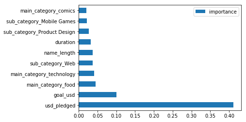

```python
top_ten.plot(kind='barh') # plot feature importances
```

Let's put this into descending order, that's a more sensible visualization since we want to know what is the most important feature is first, not last!

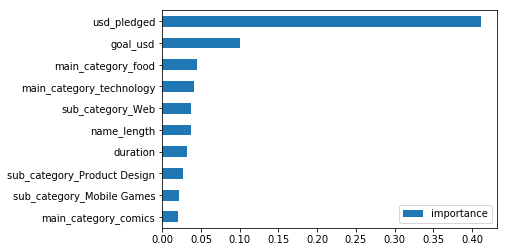

```python
top_ten.iloc[::-1].plot(kind='barh') # descending order
```

```python
feature_importances[feature_importances['importance'] <= 0] # see which features have importances <= 0
```

|  | importance |
| --- | --- |
| main_category_photography | 0.0 |
| sub_category_Zines | 0.0 |
| sub_category_Woodworking | 0.0 |
| sub_category_Webseries | 0.0 |
| sub_category_Footwear | 0.0 |
| sub_category_Audio | 0.0 |
| sub_category_Typography | 0.0 |
| sub_category_Photobooks | 0.0 |
| sub_category_Drama | 0.0 |
| sub_category_People | 0.0 |
| sub_category_Embroidery | 0.0 |
| sub_category_Nature | 0.0 |
| sub_category_Mixed Media | 0.0 |
| sub_category_Literary Spaces | 0.0 |
| sub_category_Literary Journals | 0.0 |
| sub_category_Family | 0.0 |
| sub_category_Fantasy | 0.0 |
| sub_category_Installations | 0.0 |
| sub_category_Immersive | 0.0 |
| sub_category_Film & Video | 0.0 |
| sub_category_Fine Art | 0.0 |
| sub_category_Glass | 0.0 |
| sub_category_Gaming Hardware | 0.0 |
| sub_category_Games | 0.0 |
| sub_category_Crochet | 0.0 |
| sub_category_Plays | 0.0 |
| sub_category_Pottery | 0.0 |
| sub_category_Science Fiction | 0.0 |
| sub_category_Textiles | 0.0 |
| sub_category_Calendars | 0.0 |
| sub_category_Taxidermy | 0.0 |
| sub_category_Ceramics | 0.0 |
| sub_category_Stationery | 0.0 |
| sub_category_Chiptune | 0.0 |
| sub_category_Sculpture | 0.0 |
| sub_category_Romance | 0.0 |
| sub_category_Couture | 0.0 |
| sub_category_Comedy | 0.0 |
| sub_category_R&B | 0.0 |
| sub_category_Quilts | 0.0 |
| sub_category_Puzzles | 0.0 |
| sub_category_Punk | 0.0 |
| sub_category_Public Art | 0.0 |
| sub_category_Printing | 0.0 |
| sub_category_Jewelry | 0.0 |

**Analyze Results**

- The majority of the cumulative importance comes from the top 10 features
- All the features where the importance is equal to zero are features that can contribute nothing to the model
- usd_pledged is by far the most important feature
  - This makes sense, as a kickstarter is only successful if enough money is pledged

## Step 7: Rebuild Model and Re-Run

```python
X2 = X[top_ten.index] # subset only the top 10 most important features
```

```python
top_ten.index
```

```
Index(['usd_pledged', 'goal_usd', 'main_category_food',
       'main_category_technology', 'sub_category_Web', 'name_length',
       'duration', 'sub_category_Product Design', 'sub_category_Mobile Games',
       'main_category_comics'],
      dtype='object')
```

In case you're curious of what top_ten.index returns.

```python
X2.head()
```

|  | usd_pledged | goal_usd | main_category_food | main_category_technology | sub_category_Web | name_length | duration | sub_category_Product Design | sub_category_Mobile Games | main_category_comics |
| --- | --- | --- | --- | --- | --- | --- | --- | --- | --- | --- |
| 0 | 6061.00000 | 2000.00000 | 0 | 0 | 0 | 7 | 16.0 | 0 | 0 | 0 |
| 1 | 3914.50512 | 3870.99771 | 0 | 0 | 0 | 8 | 30.0 | 0 | 0 | 1 |
| 2 | 1110.00000 | 1100.00000 | 0 | 0 | 0 | 7 | 30.0 | 0 | 0 | 0 |
| 3 | 4807.00000 | 3500.00000 | 0 | 0 | 0 | 6 | 45.0 | 0 | 0 | 0 |
| 4 | 40368.00000 | 30000.00000 | 0 | 1 | 0 | 4 | 60.0 | 0 | 0 | 0 |

```python
X_train, X_test, y_train, y_test = train_test_split(X2, y, test_size=0.25, random_state=42)
```

```python
for d in range(10): # check performance with just the 10 features
    print('**********')
    start_time = time.time()
    print('Depth: {}'.format(d+1))
    clf = RandomForestClassifier(max_depth=d+1, random_state=0)
    clf.fit(X_train, y_train)
    predicted = clf.predict(X_test)
    acc = accuracy_score(y_true=y_test, y_pred=predicted)
    print('Accuracy: {}'.format(acc))
    print('Runtime: {} seconds'.format(time.time() - start_time))
```

```
**********
Depth: 1
Accuracy: 0.7386417932151983
Runtime: 2.9355361461639404 seconds
**********
Depth: 2
Accuracy: 0.8771838710347549
Runtime: 3.646559953689575 seconds
**********
Depth: 3
Accuracy: 0.8961090221659015
Runtime: 4.097588062286377 seconds
**********
Depth: 4
Accuracy: 0.915844360886636
Runtime: 4.864296197891235 seconds
**********
Depth: 5
Accuracy: 0.9347071898955066
Runtime: 5.9620201587677 seconds
**********
Depth: 6
Accuracy: 0.9468392296985687
Runtime: 6.872283220291138 seconds
**********
Depth: 7
Accuracy: 0.9668654049899246
Runtime: 7.376497268676758 seconds
**********
Depth: 8
Accuracy: 0.9772316513284999
Runtime: 8.859715223312378 seconds
**********
Depth: 9
Accuracy: 0.9841494069011364
Runtime: 9.294850826263428 seconds
**********
Depth: 10
Accuracy: 0.9875771236263166
Runtime: 8.664931058883667 seconds
```

**Analyze Results**

- Across every depth, the accuracy is much better than before
- And, it is much more efficient and fast
- Our depth 10 accuracy gives nearly 99% accuracy and takes about as much time to run as the depth 7 random forest before
- Interestingly, the depth 10 forest actually runs faster than both the depth 8 and depth 9 forests
  - Let's use the depth 10 forest as our final model

Our accuracy increasing despite having less features indicates that we were overfitting before and not handling the variance in the test set as well.

Now, we have an efficient and accurate model.

Furthermore, this provides reason to interpret the feature_importances.

## Step 8: Calculate Prediction Quality Metrics for Model

```python
clf = RandomForestClassifier(max_depth=10, random_state=0)
clf.fit(X_train, y_train)
predicted = clf.predict(X_test)
cm = confusion_matrix(y_test, predicted)
cm
```

```
array([[18258,   581],
       [   17, 29281]])
```

- This is a step that should be taken, however I wanted to show that we can run the model without converting the dependent variable to binary

How can I tell this is the case?

Let's split this up into four variables TP, FP, FN, and TP.

```python
cm = confusion_matrix(np.ravel(y_test),predicted)
tn, fp, fn, tp = confusion_matrix(np.ravel(y_test), predicted).ravel()
```

```python
acc = (tp+tn) / (tn+fp+fn+tp)
precision = tp/(tp+fp)
recall = tp/(tp+fn)
fpr = fp/(fp+tn)
f_score = 2*precision*recall/(precision+recall)
accuracy = (tp+tn)/(tp+tn+fp+fn)
print("Precision:\t\t\t%1.2f identified as failures are failures"%(precision))
print("Recall/TPR:\t\t\t%1.2f proportion of actual failures identified"%(recall))
print("False Positive Rate:\t\t%1.2f proportion of successes identified as failures"%fpr)
print("f-score:\t\t\t%1.2f tradeoff between precision and recall"%(f_score))
print("Accuracy:\t\t\t%1.2f how well the model has classified"%(accuracy))
```

```
Precision:			0.98 identified as failures are failures
Recall/TPR:			1.00 proportion of actual failures identified
False Positive Rate:		0.03 proportion of successes identified as failures
f-score:			0.99 tradeoff between precision and recall
Accuracy:			0.99 how well the model has classified
```

Overall, this is a very strong model.

## Step 9: Interpret Original Feature Importances

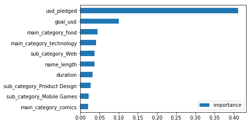

```python
top_ten.iloc[::-1].plot(kind='barh')
```

**Analyze Results**

Given the results before, we can now interpret the model as saying:

- The amount of money pledged to a campaign and the goal of the campaign are the most important factors for success
- Whether or not a kickstarter is related to food or technology is important (this is also reflected in the sub_categories here, most of which relate to technology)
- How long the name of the kickstarter campaign is and how long it is important for is an important consideration for a kickstarter

I'd like to question bullet point two above. Is there just a disproportionate amount of main categories in technology and food?

```python
df['main_category'].value_counts()
```

```
music           25850
film & video    25622
technology      19592
art             19043
publishing      18676
food            14961
games           12567
fashion         10812
comics           8168
design           7719
photography      7346
crafts           6530
theater          6451
journalism       5287
dance            3924
Name: main_category, dtype: int64
```

No there is not! So this is an interesting insight that was not obvious, but that we can now identify.

## Step 10: Summarize Client Deliverable

```python
import numpy as np
import pandas as pd
import matplotlib.pyplot as plt
from sklearn.model_selection import train_test_split
from sklearn.ensemble import RandomForestClassifier
from sklearn.metrics import accuracy_score
import time
from sklearn.metrics import confusion_matrix

df = pd.read_csv('data/kickstarter.csv')
selected_columns = ['currency', 'main_category', 'sub_category',
       'duration', 'goal_usd',
       'country', 'blurb_length', 'name_length', 'status', 'start_month',
       'end_month', 'start_Q', 'end_Q', 'usd_pledged']
df = df[selected_columns]

X = df.loc[:, df.columns != 'status']
X = pd.get_dummies(X)
X = X[['usd_pledged', 'goal_usd', 'main_category_food',
       'main_category_technology', 'sub_category_Web', 'name_length',
       'duration', 'sub_category_Product Design', 'sub_category_Mobile Games',
       'main_category_comics']]
y = df['status']

X_train, X_test, y_train, y_test = train_test_split(X, y, test_size=0.25, random_state=42)
clf = RandomForestClassifier(max_depth=d+1, random_state=0)
clf.fit(X_train, y_train)
predicted = clf.predict(X_test)

cm = confusion_matrix(np.ravel(y_test),predicted)
tn, fp, fn, tp = confusion_matrix(np.ravel(y_test), predicted).ravel()

acc = (tp+tn) / (tn+fp+fn+tp)
precision = tp/(tp+fp)
recall = tp/(tp+fn)
fpr = fp/(fp+tn)
f_score = 2*precision*recall/(precision+recall)
accuracy = (tp+tn)/(tp+tn+fp+fn)
print("Precision:\t\t\t%1.2f identified as failures are failures"%(precision))
print("Recall/TPR:\t\t\t%1.2f proportion of actual failures identified"%(recall))
print("False Positive Rate:\t\t%1.2f proportion of successes identified as failures"%fpr)
print("f-score:\t\t\t%1.2f tradeoff between precision and recall"%(f_score))
print("Accuracy:\t\t\t%1.2f how well the model has classified"%(accuracy))
```

```
Precision:			0.98 identified as failures are failures
Recall/TPR:			1.00 proportion of actual failures identified
False Positive Rate:		0.03 proportion of successes identified as failures
f-score:			0.99 tradeoff between precision and recall
Accuracy:			0.99 how well the model has classified
```

We now have a model that can predict whether or not a kickstarter campaign will be successful.

## Conclusion

In this case, we learned how to create and iterate on a random forest model. Now, LionBase can assist companies in predicting whether or not they can successfully fundraise through Kickstarter.